# Case Study: Bellabeat Fitness App

Rafael Fraga - rafaelfraga.github.io

## Business Scenario

Bellabeat is a successful small company, but they have the potential to become a larger player in the global smart device market. Urška Sršen, cofounder and Chief Creative Officer of Bellabeat, believes that analyzing smart device fitness data could help unlock new growth opportunities for the company. You have been asked to focus on one of Bellabeat’s products and analyze smart device data to gain insight into how consumers are using their smart devices. The insights you discover will then help guide marketing strategy for the company. You will present your analysis to the Bellabeat executive team along with your high-level recommendations for Bellabeat’s marketing strategy.

## Questions to be answered by this analysis

1. What are some trends in smart device usage?
2. How could these trends apply to Bellabeat customers?
3. How could these trends help influence Bellabeat marketing strategy?

## Business Task

Identify growth opportunities for a product line according to the analysis of the customers trends in device usage.

## Disclaimer

Please note that this datasets comes from the [Kaggle’s Fitbit tracker dataset](https://www.kaggle.com/arashnic/fitbit), and it lacks necessary information to optimize this task. For example, there’s no metadata accompanying this dataset. The number of respondents is limited in number, and very useful qualitative information such as age, gender, type of workout, device/app used, and also more metrics such a information necessary to assess quality of sleep are missing.

We will try to extrapolate a conclusion from the limited data available, **but would be highly recommended to expand this data gathering effort.**

## Importing Libraries

```r
library(tidyverse)
library(lubridate)
library(ggplot2)
library(GGally)
library(skimr)
library(calendR)
```

## Importing datasets

```r
#setting work directory
wd <- getwd()
```

We will first analyze data gathered with the granularity of 1 day (24hrs). This will be in order to check if the information at it’s highest level provides enough information for further investigation.

```r
sleep_daily <- read_csv(paste(wd, "/fitbase-data/sleepDay_merged.csv", sep = ""))
weight_log <- read_csv(paste( wd, "/fitbase-data/weightLogInfo_merged.csv", sep=""))
activity_daily <- read_csv(paste (wd, "/fitbase-data/dailyActivity_merged.csv", sep=""))
calories_daily <- read_csv(paste (wd, "/fitbase-data/dailyCalories_merged.csv", sep=""))
steps_daily <- read_csv(paste (wd, "/fitbase-data/dailySteps_merged.csv", sep=""))
```

## Data cleaning and transformation

### Daily Activity

```r
glimpse(activity_daily)
```

```
Rows: 940
Columns: 15
$ Id                       <dbl> 1503960366, 1503960366, 1503960366, 1503960366, 1503960366, 1503960366, 1503960366, 1503960366, 1503960366, 15039~
$ ActivityDate             <chr> "4/12/2016", "4/13/2016", "4/14/2016", "4/15/2016", "4/16/2016", "4/17/2016", "4/18/2016", "4/19/2016", "4/20/201~
$ TotalSteps               <dbl> 13162, 10735, 10460, 9762, 12669, 9705, 13019, 15506, 10544, 9819, 12764, 14371, 10039, 15355, 13755, 18134, 1315~
$ TotalDistance            <dbl> 8.50, 6.97, 6.74, 6.28, 8.16, 6.48, 8.59, 9.88, 6.68, 6.34, 8.13, 9.04, 6.41, 9.80, 8.79, 12.21, 8.53, 7.15, 9.25~
$ TrackerDistance          <dbl> 8.50, 6.97, 6.74, 6.28, 8.16, 6.48, 8.59, 9.88, 6.68, 6.34, 8.13, 9.04, 6.41, 9.80, 8.79, 12.21, 8.53, 7.15, 9.25~
$ LoggedActivitiesDistance <dbl> 0, 0, 0, 0, 0, 0, 0, 0, 0, 0, 0, 0, 0, 0, 0, 0, 0, 0, 0, 0, 0, 0, 0, 0, 0, 0, 0, 0, 0, 0, 0, 0, 0, 0, 0, 0, 0, 0,~
$ VeryActiveDistance       <dbl> 1.88, 1.57, 2.44, 2.14, 2.71, 3.19, 3.25, 3.53, 1.96, 1.34, 4.76, 2.81, 2.92, 5.29, 2.33, 6.40, 3.54, 1.06, 3.56,~
$ ModeratelyActiveDistance <dbl> 0.55, 0.69, 0.40, 1.26, 0.41, 0.78, 0.64, 1.32, 0.48, 0.35, 1.12, 0.87, 0.21, 0.57, 0.92, 0.41, 1.16, 0.50, 1.42,~
$ LightActiveDistance      <dbl> 6.06, 4.71, 3.91, 2.83, 5.04, 2.51, 4.71, 5.03, 4.24, 4.65, 2.24, 5.36, 3.28, 3.94, 5.54, 5.41, 3.79, 5.58, 4.27,~
$ SedentaryActiveDistance  <dbl> 0.00, 0.00, 0.00, 0.00, 0.00, 0.00, 0.00, 0.00, 0.00, 0.00, 0.00, 0.00, 0.00, 0.00, 0.00, 0.00, 0.00, 0.00, 0.00,~
$ VeryActiveMinutes        <dbl> 25, 21, 30, 29, 36, 38, 42, 50, 28, 19, 66, 41, 39, 73, 31, 78, 48, 16, 52, 33, 41, 50, 36, 45, 24, 37, 44, 46, 4~
$ FairlyActiveMinutes      <dbl> 13, 19, 11, 34, 10, 20, 16, 31, 12, 8, 27, 21, 5, 14, 23, 11, 28, 12, 34, 35, 15, 24, 22, 24, 6, 46, 8, 11, 31, 2~
$ LightlyActiveMinutes     <dbl> 328, 217, 181, 209, 221, 164, 233, 264, 205, 211, 130, 262, 238, 216, 279, 243, 189, 243, 217, 246, 277, 254, 203~
$ SedentaryMinutes         <dbl> 728, 776, 1218, 726, 773, 539, 1149, 775, 818, 838, 1217, 732, 709, 814, 833, 1108, 782, 815, 712, 730, 798, 816,~
$ Calories                 <dbl> 1985, 1797, 1776, 1745, 1863, 1728, 1921, 2035, 1786, 1775, 1827, 1949, 1788, 2013, 1970, 2159, 1898, 1837, 1947,~
```

We can see that Activity Date was recognized as a String, this will probably occur to every Date related column for the other frames.

```r
activity_daily <- activity_daily %>%
  mutate(ActivityDate = lubridate::mdy(ActivityDate),  Id = as.factor(Id))
```

Let’s see how many users participated in this dataset

```r
activity_users <- unique(activity_daily$Id)
activity_unique_users <- length(activity_users)

print(activity_unique_users)
```

```
[1] 33
```

### Sleep logs

```r
glimpse(sleep_daily)
```

```
Rows: 413
Columns: 5
$ Id                 <dbl> 1503960366, 1503960366, 1503960366, 1503960366, 1503960366, 1503960366, 1503960366, 1503960366, 1503960366, 1503960366,~
$ SleepDay           <chr> "4/12/2016 12:00:00 AM", "4/13/2016 12:00:00 AM", "4/15/2016 12:00:00 AM", "4/16/2016 12:00:00 AM", "4/17/2016 12:00:00~
$ TotalSleepRecords  <dbl> 1, 2, 1, 2, 1, 1, 1, 1, 1, 1, 1, 1, 1, 1, 1, 1, 1, 1, 1, 1, 1, 1, 1, 1, 1, 1, 1, 1, 1, 1, 1, 1, 3, 1, 2, 1, 1, 1, 1, 1,~
$ TotalMinutesAsleep <dbl> 327, 384, 412, 340, 700, 304, 360, 325, 361, 430, 277, 245, 366, 341, 404, 369, 277, 273, 247, 334, 331, 594, 338, 383,~
$ TotalTimeInBed     <dbl> 346, 407, 442, 367, 712, 320, 377, 364, 384, 449, 323, 274, 393, 354, 425, 396, 309, 296, 264, 367, 349, 611, 342, 403,~
```

Converting Sleepday to date type:

```r
sleep_daily <- sleep_daily %>%
  mutate(SleepDay = lubridate::mdy_hms(SleepDay), Id = as.factor(Id))
```

Checking for NA values

```r
na_count <- sapply(sleep_daily, function(x) sum(is.na(x)))
print(na_count)
```

```
                Id           SleepDay  TotalSleepRecords TotalMinutesAsleep     TotalTimeInBed
                 0                  0                  0                  0                  0
```

```r
sleep_users <- unique(sleep_daily$Id)
sleep_unique_users <- length(sleep_users)
print(sleep_unique_users)
```

```
[1] 24
```

### Weight Log

```r
glimpse(weight_log)
```

```
Rows: 67
Columns: 8
$ Id             <dbl> 1503960366, 1503960366, 1927972279, 2873212765, 2873212765, 4319703577, 4319703577, 4558609924, 4558609924, 4558609924, 455~
$ Date           <chr> "5/2/2016 11:59:59 PM", "5/3/2016 11:59:59 PM", "4/13/2016 1:08:52 AM", "4/21/2016 11:59:59 PM", "5/12/2016 11:59:59 PM", "~
$ WeightKg       <dbl> 52.6, 52.6, 133.5, 56.7, 57.3, 72.4, 72.3, 69.7, 70.3, 69.9, 69.2, 69.1, 90.7, 62.5, 62.1, 61.7, 61.5, 62.0, 61.4, 61.2, 61~
$ WeightPounds   <dbl> 115.9631, 115.9631, 294.3171, 125.0021, 126.3249, 159.6147, 159.3942, 153.6622, 154.9850, 154.1031, 152.5599, 152.3394, 199~
$ Fat            <dbl> 22, NA, NA, NA, NA, 25, NA, NA, NA, NA, NA, NA, NA, NA, NA, NA, NA, NA, NA, NA, NA, NA, NA, NA, NA, NA, NA, NA, NA, NA, NA,~
$ BMI            <dbl> 22.65, 22.65, 47.54, 21.45, 21.69, 27.45, 27.38, 27.25, 27.46, 27.32, 27.04, 27.00, 28.00, 24.39, 24.24, 24.10, 24.00, 24.2~
$ IsManualReport <lgl> TRUE, TRUE, FALSE, TRUE, TRUE, TRUE, TRUE, TRUE, TRUE, TRUE, TRUE, TRUE, FALSE, TRUE, TRUE, TRUE, TRUE, TRUE, TRUE, TRUE, T~
$ LogId          <dbl> 1462233599000, 1462319999000, 1460509732000, 1461283199000, 1463097599000, 1460937599000, 1462406399000, 1461023999000, 146~
```

Converting Date to date-time type:

```r
weight_log <- weight_log %>%
  mutate(Date = lubridate::mdy_hms(Date, tz=Sys.timezone()), Id = as.factor(Id))

weight_log$Date <- round_date(weight_log$Date, "day")
```

Checking for NA values

```r
na_count <- sapply(weight_log, function(x) sum(is.na(x)))
print(na_count)
```

```
            Id           Date       WeightKg   WeightPounds            Fat            BMI IsManualReport          LogId
             0              0              0              0             65              0              0              0
```

We have only Logs for 2 values of body fat percentage, because of this this column is insignificant for the analysis and will be dropped.

```r
weight_log <-  weight_log %>%
  select(-Fat)
```

Counting Unique users

```r
weight_users <- unique(weight_log$Id)
weight_unique_users <- length(weight_users)
print(weight_unique_users)
```

```
[1] 8
```

### Daily Steps

```r
glimpse(steps_daily)
```

```
Rows: 940
Columns: 3
$ Id          <dbl> 1503960366, 1503960366, 1503960366, 1503960366, 1503960366, 1503960366, 1503960366, 1503960366, 1503960366, 1503960366, 150396~
$ ActivityDay <chr> "4/12/2016", "4/13/2016", "4/14/2016", "4/15/2016", "4/16/2016", "4/17/2016", "4/18/2016", "4/19/2016", "4/20/2016", "4/21/201~
$ StepTotal   <dbl> 13162, 10735, 10460, 9762, 12669, 9705, 13019, 15506, 10544, 9819, 12764, 14371, 10039, 15355, 13755, 18134, 13154, 11181, 146~
```

Converting ActivityDay to date format.

```r
steps_daily <- steps_daily %>%
  mutate(ActivityDay  = lubridate::mdy(ActivityDay), Id = as.factor(Id))
```

Checking for NA values

```r
na_count <- sapply(steps_daily, function(x) sum(is.na(x)))
print(na_count)
```

```
         Id ActivityDay   StepTotal
          0           0           0
```

```r
step_users <- unique(steps_daily$Id)
step_unique_users <- length(step_users)
print(step_unique_users)
```

```
[1] 33
```

## Exploratory Data Analysis

> I will use the exploratory approach to data, firstly understanding the correlations of data and trying to find patterns trough questions. Then, we will try to apply this insights into a useful business action.

### Initial questions

At the beginning of this analysis, and research the domain subject, I already have some questions:

**Does regular physical activity lead to better sleep?**  
**Is the userbase, in general, more sedentary or active?**  
**How related are regular physical activity, sleep and weight loss?**

### Exploring subsets of participants

First we can look for which subset of users we can work. Since our databases don’t necessarily contains the same set of unique IDs.

```r
#The subset of the users who submitted all of their daily data
submitted_complete_data <- length(Reduce(intersect, list(weight_users, activity_users, sleep_users, step_users)))

#Subset of users who submitted activity, sleep and step

submitted_activity_sleep_steps <- length(Reduce(intersect, list(activity_users, sleep_users, step_users)))

#Subset of users who submitted activity and sleep

submitted_activity_sleep <- length(Reduce(intersect, list(activity_users, sleep_users)))

writeLines(paste0("Submitted all daily data: ", submitted_complete_data, " users\nSubmitted all data except weight: ", submitted_activity_sleep_steps, " users\nSubmitted only activity and sleep data: ", submitted_activity_sleep, " users") )
```

```
Submitted all daily data: 6 users
Submitted all data except weight: 24 users
Submitted only activity and sleep data: 24 users
```

### Joining Dataframes to simplify workflow

```r
merged_sleep_activity_daily <- inner_join(activity_daily, sleep_daily, by = c("Id" = "Id", "ActivityDate" = "SleepDay"))
merged_sleep_activity_daily <- mutate(merged_sleep_activity_daily, Id = as.factor(Id))
head(merged_sleep_activity_daily)
```

| Id | ActivityDate | TotalSteps | TotalDistance | TrackerDistance | LoggedActivitiesDistance | VeryActiveDistance | ModeratelyActiveDistance | LightActiveDistance | SedentaryActiveDistance | VeryActiveMinutes | FairlyActiveMinutes | LightlyActiveMinutes | SedentaryMinutes | Calories | TotalSleepRecords | TotalMinutesAsleep | TotalTimeInBed |
| --- | --- | --- | --- | --- | --- | --- | --- | --- | --- | --- | --- | --- | --- | --- | --- | --- | --- |
| 1503960366 | 2016-04-12 | 13162 | 8.50 | 8.50 | 0 | 1.88 | 0.55 | 6.06 | 0 | 25 | 13 | 328 | 728 | 1985 | 1 | 327 | 346 |
| 1503960366 | 2016-04-13 | 10735 | 6.97 | 6.97 | 0 | 1.57 | 0.69 | 4.71 | 0 | 21 | 19 | 217 | 776 | 1797 | 2 | 384 | 407 |
| 1503960366 | 2016-04-15 | 9762 | 6.28 | 6.28 | 0 | 2.14 | 1.26 | 2.83 | 0 | 29 | 34 | 209 | 726 | 1745 | 1 | 412 | 442 |
| 1503960366 | 2016-04-16 | 12669 | 8.16 | 8.16 | 0 | 2.71 | 0.41 | 5.04 | 0 | 36 | 10 | 221 | 773 | 1863 | 2 | 340 | 367 |
| 1503960366 | 2016-04-17 | 9705 | 6.48 | 6.48 | 0 | 3.19 | 0.78 | 2.51 | 0 | 38 | 20 | 164 | 539 | 1728 | 1 | 700 | 712 |
| 1503960366 | 2016-04-19 | 15506 | 9.88 | 9.88 | 0 | 3.53 | 1.32 | 5.03 | 0 | 50 | 31 | 264 | 775 | 2035 | 1 | 304 | 320 |

```r
options(scipen = 999)
skim(merged_sleep_activity_daily)
```

```
-- Data Summary ------------------------
                           Values
Name                       merged_sleep_activity_dai...
Number of rows             413
Number of columns          18
_______________________
Column type frequency:
  factor                   1
  numeric                  16
  POSIXct                  1
________________________
Group variables            None

-- Variable type: factor ---------------------------------------------------------------------------------------------------------------------------
# A tibble: 1 x 6
  skim_variable n_missing complete_rate ordered n_unique top_counts
* <chr>             <int>         <dbl> <lgl>      <int> <chr>
1 Id                    0             1 FALSE         24 837: 32, 555: 31, 696: 31, 202: 28

-- Variable type: numeric --------------------------------------------------------------------------------------------------------------------------
# A tibble: 16 x 11
   skim_variable            n_missing complete_rate        mean         sd       p0     p25      p50      p75      p100 hist
 * <chr>                        <int>         <dbl>       <dbl>      <dbl>    <dbl>   <dbl>    <dbl>    <dbl>     <dbl> <chr>
 1 TotalSteps                       0             1 8541.       4157.       17      5206    8925     11393    22770     ▅▆▇▂▁
 2 TotalDistance                    0             1    6.04        3.05      0.0100    3.60    6.29      8.03    17.5   ▅▇▇▁▁
 3 TrackerDistance                  0             1    6.03        3.05      0.0100    3.60    6.29      8.02    17.5   ▅▇▇▁▁
 4 LoggedActivitiesDistance         0             1    0.113       0.513     0         0       0         0        4.08  ▇▁▁▁▁
 5 VeryActiveDistance               0             1    1.45        1.99      0         0       0.570     2.37    12.5   ▇▂▁▁▁
 6 ModeratelyActiveDistance         0             1    0.750       1.00      0         0       0.420     1.04     6.48  ▇▂▁▁▁
 7 LightActiveDistance              0             1    3.81        1.73      0.0100    2.54    3.68      4.93     9.48  ▂▇▆▂▁
 8 SedentaryActiveDistance          0             1    0.000920    0.00865   0         0       0         0        0.110 ▇▁▁▁▁
 9 VeryActiveMinutes                0             1   25.2        36.4       0         0       9        38      210     ▇▂▁▁▁
10 FairlyActiveMinutes              0             1   18.0        22.4       0         0      11        27      143     ▇▂▁▁▁
11 LightlyActiveMinutes             0             1  217.         87.2       2       158     208       263      518     ▂▇▇▂▁
12 SedentaryMinutes                 0             1  712.        166.        0       631     717       783     1265     ▁▁▇▃▁
13 Calories                         0             1 2398.        763.      257      1850    2220      2926     4900     ▁▇▇▃▁
14 TotalSleepRecords                0             1    1.12        0.346     1         1       1         1        3     ▇▁▁▁▁
15 TotalMinutesAsleep               0             1  419.        118.       58       361     433       490      796     ▁▂▇▃▁
16 TotalTimeInBed                   0             1  459.        127.       61       403     463       526      961     ▁▃▇▁▁

-- Variable type: POSIXct --------------------------------------------------------------------------------------------------------------------------
# A tibble: 1 x 7
  skim_variable n_missing complete_rate min                 max                 median              n_unique
* <chr>             <int>         <dbl> <dttm>              <dttm>              <dttm>                 <int>
1 ActivityDate          0             1 2016-04-12 00:00:00 2016-05-12 00:00:00 2016-04-27 00:00:00       31
```

### Question 1

#### Is the userbase, in general, more sedentary or active?

```r
#counting the amount of users with more than 10k steps per day

average_steps <- merged_sleep_activity_daily %>%
  group_by(Id) %>%
  summarise(mean_steps_day = mean(TotalSteps, na.rm = TRUE))

summary(average_steps$mean_steps_day)
```

```
   Min. 1st Qu.  Median    Mean 3rd Qu.    Max.
   1490    5106    8336    7890    9394   19079
```

```r
users_active <- filter(average_steps, mean_steps_day > 10000)
users_active_percent <- (nrow(users_active)/nrow(average_steps))*100

writeLines(paste0("\n Only ", nrow(users_active)," or " ,users_active_percent, " % of 'active' users (according to the OMS standards)"))
```

```
 Only 5 or 20.8333333333333 % of 'active' users (according to the OMS standards)
```

**Initially we can derive the following insights:**

[output not shown]

```r
activity_type <- merged_sleep_activity_daily %>%
  select(Id, LightlyActiveMinutes, FairlyActiveMinutes, VeryActiveMinutes) %>%
  group_by(Id) %>%
  summarise_all(~mean(., na.rm = FALSE))

summary(activity_type)
```

```
          Id     LightlyActiveMinutes FairlyActiveMinutes VeryActiveMinutes
 1503960366: 1   Min.   : 82.67       Min.   : 0.000      Min.   :  0.000
 1644430081: 1   1st Qu.:168.34       1st Qu.: 2.417      1st Qu.:  2.250
 1844505072: 1   Median :219.25       Median :13.500      Median :  9.767
 1927972279: 1   Mean   :208.81       Mean   :15.001      Mean   : 21.823
 2026352035: 1   3rd Qu.:244.68       3rd Qu.:20.533      3rd Qu.: 24.273
 2320127002: 1   Max.   :359.67       Max.   :61.286      Max.   :111.667
 (Other)   :18
```

- Still in accordance with the WHO guidelines, the organization states:

> “Do at least 30 minutes of moderate-intensity physical activity on five or more days each week.”
- That would be sum of Fair and Active minutes of activity. The median activity per day, per user falls short by 6.74min (23.26min), and the mean supersedes it by 6.8min (36.8min). This disparity can be attributed by some outlier users who seem to dedicate a lot to Very intense activities for more than 25min a day. Because of this, we will take the median time in consideration.

> Bellabeat customers, in general, **do not surpass the minimum recommended physical activity time recommended by the WHO.**

### Question 2

#### Does regular physical activity lead to better sleep?

##### How to ‘calculate’ sleep quality?

Some smart wearebles, such as [Xiaomi’s Mi Band 6] (https://www.mi.com/uk/mi-smart-band-6/overview), can give to the user metrics such as sleep breathing score, time in REM sleep, and oxygen saturation levels. This information is not available in this dataset. So, we will measure the quality of sleep as: $SleepQuality = TotalMinutesAsleep / TotalTimeInBed$ and compare with the daily amount of steps and calories burned per day.

```r
#creating calculated column
merged_sleep_activity_daily <- merged_sleep_activity_daily %>%
  mutate(
    SleepQuality = TotalMinutesAsleep / TotalTimeInBed
  )

head(merged_sleep_activity_daily)
```

| Id | ActivityDate | TotalSteps | TotalDistance | TrackerDistance | LoggedActivitiesDistance | VeryActiveDistance | ModeratelyActiveDistance | LightActiveDistance | SedentaryActiveDistance | VeryActiveMinutes | FairlyActiveMinutes | LightlyActiveMinutes | SedentaryMinutes | Calories | TotalSleepRecords | TotalMinutesAsleep | TotalTimeInBed | SleepQuality |
| --- | --- | --- | --- | --- | --- | --- | --- | --- | --- | --- | --- | --- | --- | --- | --- | --- | --- | --- |
| 1503960366 | 2016-04-12 | 13162 | 8.50 | 8.50 | 0 | 1.88 | 0.55 | 6.06 | 0 | 25 | 13 | 328 | 728 | 1985 | 1 | 327 | 346 | 0.9450867 |
| 1503960366 | 2016-04-13 | 10735 | 6.97 | 6.97 | 0 | 1.57 | 0.69 | 4.71 | 0 | 21 | 19 | 217 | 776 | 1797 | 2 | 384 | 407 | 0.9434889 |
| 1503960366 | 2016-04-15 | 9762 | 6.28 | 6.28 | 0 | 2.14 | 1.26 | 2.83 | 0 | 29 | 34 | 209 | 726 | 1745 | 1 | 412 | 442 | 0.9321267 |
| 1503960366 | 2016-04-16 | 12669 | 8.16 | 8.16 | 0 | 2.71 | 0.41 | 5.04 | 0 | 36 | 10 | 221 | 773 | 1863 | 2 | 340 | 367 | 0.9264305 |
| 1503960366 | 2016-04-17 | 9705 | 6.48 | 6.48 | 0 | 3.19 | 0.78 | 2.51 | 0 | 38 | 20 | 164 | 539 | 1728 | 1 | 700 | 712 | 0.9831461 |
| 1503960366 | 2016-04-19 | 15506 | 9.88 | 9.88 | 0 | 3.53 | 1.32 | 5.03 | 0 | 50 | 31 | 264 | 775 | 2035 | 1 | 304 | 320 | 0.9500000 |

##### Visualizing general sleeping habits

```r
  summary(merged_sleep_activity_daily$SleepQuality)
```

```
   Min. 1st Qu.  Median    Mean 3rd Qu.    Max.
 0.4984  0.9122  0.9431  0.9168  0.9607  1.0000
```

- In general users spend between 4% and 8.9% of their time on the bed *probably* trying to sleep.

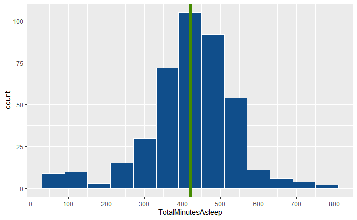

```r
ggplot(data = merged_sleep_activity_daily, aes(x = TotalMinutesAsleep )) + geom_histogram(binwidth = 60, fill = 'dodgerblue4',col=I("white")) + scale_x_continuous(breaks=seq(from = 0, to = 900, by = 100)) + geom_vline(mapping = aes(xintercept = 420), color = 'chartreuse4', size = 2)
```

```r
summary(merged_sleep_activity_daily$TotalMinutesAsleep)
```

```
   Min. 1st Qu.  Median    Mean 3rd Qu.    Max.
   58.0   361.0   433.0   419.5   490.0   796.0
```

- The green line, 420min or 7hrs, represents the minimum recommended by the Academy of Sleep Medicine (AASM) of time asleep.

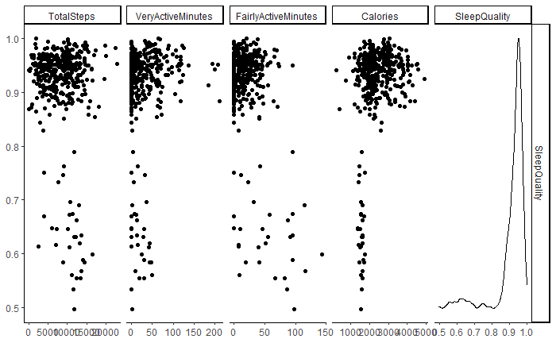

```r
primary_var <- "SleepQuality"
pairs <- ggpairs(merged_sleep_activity_daily, columns = c(3,11,12,15,19))
pvar_pos <- match(primary_var, pairs$xAxisLabels)
plots <- lapply(1:pairs$ncol, function(j) getPlot(pairs, i = pvar_pos, j = j))
ggmatrix(
    plots,
    nrow = 1,
    ncol = pairs$ncol,
    xAxisLabels = pairs$xAxisLabels,
    yAxisLabels = primary_var

) + theme_classic()
```

```r
#credit goes to user https://stackoverflow.com/users/7311767/stephen-rauch and https://stackoverflow.com/users/6938922/allen-baron
```

###### From this visualization we can conclude that, using this metric cited previously, there’s no correlation between activity and SleepQuality.

> Since data on sleep quality is limited, I believe that is not productive to focus on sleep quality aspect for a business opportunity.

### Question 3

#### How correlated are regular physical activity, sleep and weight loss?

##### Joining weight data

```r
full_daily_merged = inner_join(merged_sleep_activity_daily, weight_log, by = c("Id" = "Id", "ActivityDate" = "Date"))
full_daily_merged$Id = as.factor(full_daily_merged$Id)
print(n_unique(full_daily_merged$Id))
```

[output not shown]

As we know, only 6 users reported complete data to this study. Given that our data is limited, we will extrapolate the conclusions for the userbase. **The recommendation still is to gather more data, for more precision and clarity.**

### Question 4

#### What is the relation between sleep time, calories burned and steps taken vs RHR

RHR: Resting Heart Rate

#### Heartrate by second

```r
hearthrate <- read.csv(paste0(wd, "/fitbase-data/heartrate_seconds_merged.csv"))
hearthrate <- hearthrate %>%
  mutate(Time = lubridate::mdy_hms(Time, tz=Sys.timezone()), Id = as.factor(Id))

head(hearthrate)
```

|  | Id | Time | Value |
| --- | --- | --- | --- |
| 1 | 2022484408 | 2016-04-12 07:21:00 | 97 |
| 2 | 2022484408 | 2016-04-12 07:21:05 | 102 |
| 3 | 2022484408 | 2016-04-12 07:21:10 | 105 |
| 4 | 2022484408 | 2016-04-12 07:21:20 | 103 |
| 5 | 2022484408 | 2016-04-12 07:21:25 | 101 |
| 6 | 2022484408 | 2016-04-12 07:22:05 | 95 |

#### Intensity by minute

```r
intensity <- read.csv(paste0(wd, "/fitbase-data/minuteIntensitiesNarrow_merged.csv"))

intensity <- intensity %>%
  mutate(ActivityMinute = lubridate::mdy_hms(ActivityMinute, tz=Sys.timezone()), Id = as.factor(Id))

head(intensity)
```

|  | Id | ActivityMinute | Intensity |
| --- | --- | --- | --- |
| 1 | 1503960366 | 2016-04-12 00:00:00 | 0 |
| 2 | 1503960366 | 2016-04-12 00:01:00 | 0 |
| 3 | 1503960366 | 2016-04-12 00:02:00 | 0 |
| 4 | 1503960366 | 2016-04-12 00:03:00 | 0 |
| 5 | 1503960366 | 2016-04-12 00:04:00 | 0 |
| 6 | 1503960366 | 2016-04-12 00:05:00 | 0 |

```r
skim(hearthrate)
```

```
-- Data Summary ------------------------
                           Values
Name                       hearthrate
Number of rows             2483658
Number of columns          3
_______________________
Column type frequency:
  factor                   1
  numeric                  1
  POSIXct                  1
________________________
Group variables            None

-- Variable type: factor ---------------------------------------------------------------------------------------------------------------------------
# A tibble: 1 x 6
  skim_variable n_missing complete_rate ordered n_unique top_counts
* <chr>             <int>         <dbl> <lgl>      <int> <chr>
1 Id                    0             1 FALSE         14 402: 285461, 696: 266326, 555: 255174, 438: 249748

-- Variable type: numeric --------------------------------------------------------------------------------------------------------------------------
# A tibble: 1 x 11
  skim_variable n_missing complete_rate  mean    sd    p0   p25   p50   p75  p100 hist
* <chr>             <int>         <dbl> <dbl> <dbl> <dbl> <dbl> <dbl> <dbl> <dbl> <chr>
1 Value                 0             1  77.3  19.4    36    63    73    88   203 ▇▇▁▁▁

-- Variable type: POSIXct --------------------------------------------------------------------------------------------------------------------------
# A tibble: 1 x 7
  skim_variable n_missing complete_rate min                 max                 median              n_unique
* <chr>             <int>         <dbl> <dttm>              <dttm>              <dttm>                 <int>
1 Time                  0             1 2016-04-12 00:00:00 2016-05-12 16:20:00 2016-04-26 20:28:50   961274
```

```r
skim(intensity)
```

```
-- Data Summary ------------------------
                           Values
Name                       intensity
Number of rows             1325580
Number of columns          3
_______________________
Column type frequency:
  factor                   1
  numeric                  1
  POSIXct                  1
________________________
Group variables            None

-- Variable type: factor ---------------------------------------------------------------------------------------------------------------------------
# A tibble: 1 x 6
  skim_variable n_missing complete_rate ordered n_unique top_counts
* <chr>             <int>         <dbl> <lgl>      <int> <chr>
1 Id                    0             1 FALSE         33 162: 44160, 192: 44160, 202: 44160, 287: 44160

-- Variable type: numeric --------------------------------------------------------------------------------------------------------------------------
# A tibble: 1 x 11
  skim_variable n_missing complete_rate  mean    sd    p0   p25   p50   p75  p100 hist
* <chr>             <int>         <dbl> <dbl> <dbl> <dbl> <dbl> <dbl> <dbl> <dbl> <chr>
1 Intensity             0             1 0.201 0.519     0     0     0     0     3 ▇▁▁▁▁

-- Variable type: POSIXct --------------------------------------------------------------------------------------------------------------------------
# A tibble: 1 x 7
  skim_variable  n_missing complete_rate min                 max                 median              n_unique
* <chr>              <int>         <dbl> <dttm>              <dttm>              <dttm>                 <int>
1 ActivityMinute         0             1 2016-04-12 00:00:00 2016-05-12 15:59:00 2016-04-26 06:27:00    44160
```

We will consider intensity = 0 as “resting”.

#### Joining the dataframes

```r
merged_heartrate_activity_min <- inner_join(x=hearthrate, y=intensity, by=c("Id" = "Id", "Time" = "ActivityMinute"))
head(merged_heartrate_activity_min)
```

|  | Id | Time | Value | Intensity |
| --- | --- | --- | --- | --- |
| 1 | 2022484408 | 2016-04-12 07:21:00 | 97 | 1 |
| 2 | 2022484408 | 2016-04-12 07:23:00 | 60 | 0 |
| 3 | 2022484408 | 2016-04-12 07:24:00 | 58 | 0 |
| 4 | 2022484408 | 2016-04-12 07:26:00 | 53 | 1 |
| 5 | 2022484408 | 2016-04-12 07:27:00 | 53 | 0 |
| 6 | 2022484408 | 2016-04-12 07:28:00 | 60 | 1 |

#### Calculating the average RHR for each user, by day.

```r
user_avg_rhr <- merged_heartrate_activity_min %>%
  subset(Intensity == 0) %>%
  mutate(Time = round_date(Time, "day")) %>%
  group_by(Id, Time) %>%
  summarise(daily_avg_rhr = mean(Value))
head(user_avg_rhr)
```

| Id | Time | daily_avg_rhr |
| --- | --- | --- |
| 2022484408 | 2016-04-12 | 63.46392 |
| 2022484408 | 2016-04-13 | 67.52000 |
| 2022484408 | 2016-04-14 | 66.20769 |
| 2022484408 | 2016-04-15 | 65.41152 |
| 2022484408 | 2016-04-16 | 67.36017 |
| 2022484408 | 2016-04-17 | 66.11927 |

Calculating RHR in general for each user

#### Classifying RHR for each user

###### According to Harvard Heatlh Publishing:

> A normal heart rate is usually stated as 60 to 100 beats per minute. Slower than 60 is bradycardia (“slow heart”); faster than 100 is tachycardia (“fast heart”). But some experts believe that an ideal resting heart rate is closer to 50 to 70.

[Source](https://www.health.harvard.edu/heart-health/hows-your-heart-rate-and-why-it-matters)

```r
user_heartrate_info <- user_avg_rhr %>%
  group_by(Id) %>%
  summarise(rhr = mean(daily_avg_rhr)) %>%
  mutate(rhr_classification = case_when(
    rhr < 50 | rhr > 100 ~ "Abnormal",
    rhr > 70 ~ "At risk",
    rhr > 50 & rhr < 70 ~ "Normal"

  ))

user_heartrate_info
```

| Id | rhr | rhr_classification |
| --- | --- | --- |
| 2022484408 | 68.71493 | Normal |
| 2026352035 | 83.76793 | At risk |
| 2347167796 | 70.19728 | At risk |
| 4020332650 | 79.97334 | At risk |
| 4388161847 | 59.81378 | Normal |
| 4558609924 | 74.76099 | At risk |
| 5553957443 | 62.13735 | Normal |
| 5577150313 | 58.92115 | Normal |
| 6117666160 | 78.00731 | At risk |
| 6775888955 | 83.82894 | At risk |

[output cut: 4 more lines]

#### Calculating mean stes, sleep, calories etc and sedentary minutes, sleep for each user

```r
user_avg_activity_sleep <- merged_sleep_activity_daily %>%
  group_by(Id, ActivityDate)

user_activy_sleep_info <- user_avg_activity_sleep %>%
  group_by(Id) %>%
  summarise_all(mean)

user_activy_sleep_info <-  user_activy_sleep_info %>% select(-ActivityDate)
head(user_activy_sleep_info)
```

| Id | TotalSteps | TotalDistance | TrackerDistance | LoggedActivitiesDistance | VeryActiveDistance | ModeratelyActiveDistance | LightActiveDistance | SedentaryActiveDistance | VeryActiveMinutes | FairlyActiveMinutes | LightlyActiveMinutes | SedentaryMinutes | Calories | TotalSleepRecords | TotalMinutesAsleep | TotalTimeInBed | SleepQuality |
| --- | --- | --- | --- | --- | --- | --- | --- | --- | --- | --- | --- | --- | --- | --- | --- | --- | --- |
| 1503960366 | 12405.680 | 7.971200 | 7.971200 | 0 | 2.772000003 | 0.84719999 | 4.346000 | 0 | 37.9200000 | 20.2800000 | 233.12 | 759.2800 | 1872.280 | 1.08 | 360.2800 | 383.2000 | 0.9363853 |
| 1644430081 | 7967.750 | 5.792500 | 5.792500 | 0 | 0.174999999 | 0.86250003 | 4.750000 | 0 | 2.5000000 | 19.5000000 | 241.25 | 920.5000 | 2977.750 | 1.00 | 294.0000 | 346.0000 | 0.8820404 |
| 1844505072 | 3477.000 | 2.303333 | 2.303333 | 0 | 0.000000000 | 0.08666666 | 2.213333 | 0 | 0.0000000 | 2.3333333 | 145.00 | 443.3333 | 1676.333 | 1.00 | 652.0000 | 961.0000 | 0.6784599 |
| 1927972279 | 1490.000 | 1.032000 | 1.032000 | 0 | 0.000000000 | 0.00000000 | 1.032000 | 0 | 0.0000000 | 0.0000000 | 85.00 | 977.2000 | 2316.200 | 1.60 | 417.0000 | 437.8000 | 0.9470081 |
| 2026352035 | 5618.679 | 3.487143 | 3.487143 | 0 | 0.006785714 | 0.01250000 | 3.466429 | 0 | 0.1071429 | 0.2857143 | 256.50 | 653.9643 | 1540.786 | 1.00 | 506.1786 | 537.6429 | 0.9413414 |
| 2320127002 | 5079.000 | 3.420000 | 3.420000 | 0 | 0.000000000 | 0.00000000 | 3.420000 | 0 | 0.0000000 | 0.0000000 | 242.00 | 1129.0000 | 1804.000 | 1.00 | 61.0000 | 69.0000 | 0.8840580 |

#### Joining user info dataframes

```r
user_info <- inner_join(user_heartrate_info, user_activy_sleep_info, by = 'Id')
user_info
```

| Id | rhr | rhr_classification | TotalSteps | TotalDistance | TrackerDistance | LoggedActivitiesDistance | VeryActiveDistance | ModeratelyActiveDistance | LightActiveDistance | SedentaryActiveDistance | VeryActiveMinutes | FairlyActiveMinutes | LightlyActiveMinutes | SedentaryMinutes | Calories | TotalSleepRecords | TotalMinutesAsleep | TotalTimeInBed | SleepQuality |
| --- | --- | --- | --- | --- | --- | --- | --- | --- | --- | --- | --- | --- | --- | --- | --- | --- | --- | --- | --- |
| 2026352035 | 83.76793 | At risk | 5618.679 | 3.487143 | 3.487143 | 0.0000000 | 0.006785714 | 0.01250000 | 3.466429 | 0.000000000 | 0.1071429 | 0.2857143 | 256.50000 | 653.9643 | 1540.786 | 1.000000 | 506.1786 | 537.6429 | 0.9413414 |
| 2347167796 | 70.19728 | At risk | 8533.200 | 5.681333 | 5.681333 | 0.0000000 | 0.729333332 | 0.85466667 | 4.098667 | 0.000000000 | 9.2000000 | 16.1333333 | 245.86667 | 628.4000 | 1971.333 | 1.000000 | 446.8000 | 491.3333 | 0.9103704 |
| 4020332650 | 79.97334 | At risk | 6596.750 | 4.731250 | 4.731250 | 0.0000000 | 0.486249987 | 0.41624999 | 3.770000 | 0.021250000 | 15.0000000 | 15.5000000 | 218.50000 | 841.8750 | 3195.000 | 1.000000 | 349.3750 | 379.7500 | 0.9303576 |
| 4388161847 | 59.81378 | Normal | 10974.708 | 8.539167 | 8.539167 | 0.0000000 | 2.040416665 | 0.94874999 | 5.550417 | 0.000000000 | 26.8333333 | 21.2916667 | 238.62500 | 751.4583 | 3131.625 | 1.291667 | 403.1250 | 426.2083 | 0.9474141 |
| 4558609924 | 74.76099 | At risk | 8139.000 | 5.382000 | 5.382000 | 0.0000000 | 0.733999985 | 1.07000000 | 3.578000 | 0.000000000 | 19.8000000 | 25.2000000 | 268.00000 | 1028.4000 | 2197.000 | 1.000000 | 127.6000 | 140.0000 | 0.9071277 |
| 5553957443 | 62.13735 | Normal | 8612.581 | 5.639677 | 5.639677 | 0.0000000 | 1.464193549 | 0.66903226 | 3.504516 | 0.000000000 | 23.4193548 | 13.0000000 | 206.19355 | 668.3548 | 1875.677 | 1.225806 | 463.4839 | 505.8710 | 0.9152073 |
| 5577150313 | 58.92115 | Normal | 9260.077 | 6.928462 | 6.928462 | 0.0000000 | 3.463461530 | 0.74153847 | 2.707692 | 0.000000000 | 97.8846154 | 33.3846154 | 164.96154 | 667.3077 | 3539.192 | 1.038462 | 432.0000 | 460.6154 | 0.9392115 |
| 6117666160 | 78.00731 | At risk | 8823.833 | 6.695000 | 6.695000 | 0.0000000 | 0.199444443 | 0.09611111 | 5.953889 | 0.000000000 | 2.4444444 | 2.4444444 | 359.66667 | 531.9444 | 2460.833 | 1.222222 | 478.7778 | 510.1667 | 0.9401978 |
| 6775888955 | 83.82894 | At risk | 3499.000 | 2.510000 | 2.510000 | 0.0000000 | 0.660000006 | 0.48000000 | 1.370000 | 0.000000000 | 10.3333333 | 14.0000000 | 82.66667 | 964.0000 | 2344.667 | 1.000000 | 349.6667 | 369.0000 | 0.9420280 |
| 6962181067 | 69.49756 | Normal | 9794.806 | 6.585806 | 6.519355 | 0.3236997 | 1.616451619 | 0.95999999 | 4.001613 | 0.006774194 | 22.8064516 | 18.5161290 | 245.80645 | 662.3226 | 1982.032 | 1.096774 | 448.0000 | 466.1290 | 0.9614872 |

[output cut: 2 more lines]

We can derive conclusion from a subset of 12 users who submitted activity, sleep and heartrate data

#### Users in risk of cardiovascular diseases

According to a article from Mayo clinic about Cardiorespiratory Fitness (CRF) and Resting Heart Rate (RHR):

“Highest cardiorespiratory fitness (CRF) with lower mortality was found in individuals with a RHR <60 bpm. Similarly, participants with a higher RHR, >80 bpm, were at greater risk for both CVD and all-cause mortality when compared with RHR <60 bpm.”.

Other sources (i.e Harvard medical publish) cite that a RHR higher than 70bpm already has increased risk of cardiovascular diseases. For this visualization we will use this more conservative metric.

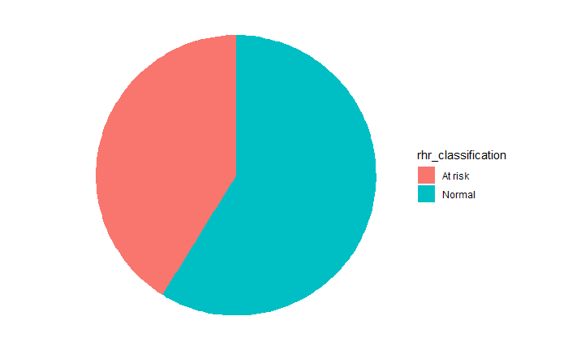

```r
ggplot(data = user_info, aes(x="", y=rhr_classification, fill=rhr_classification)) +
  geom_bar(stat="identity", width=1) +
  coord_polar("y", start=0) +
  theme_void()
```

```r
user_info$rhr_classification <- as.factor(user_info$rhr_classification)
skim(user_info$rhr_classification)
```

```
-- Data Summary ------------------------
                           Values
Name                       user_info$rhr_classificat...
Number of rows             12
Number of columns          1
_______________________
Column type frequency:
  factor                   1
________________________
Group variables            None

-- Variable type: factor ---------------------------------------------------------------------------------------------------------------------------
# A tibble: 1 x 6
  skim_variable n_missing complete_rate ordered n_unique top_counts
* <chr>             <int>         <dbl> <lgl>      <int> <chr>
1 data                  0             1 FALSE          2 At : 7, Nor: 5
```

#### Sedentarism vs RHR

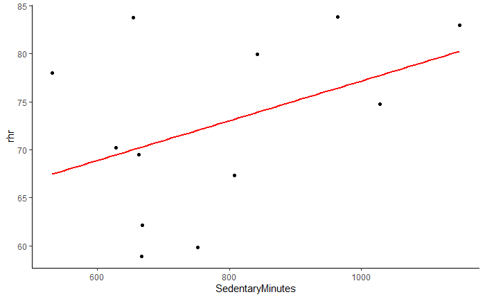

```r
ggplot(user_info, aes(x = SedentaryMinutes, y = rhr)) + geom_point() + geom_smooth(method=lm , color="red", se=FALSE) + theme_classic()
```

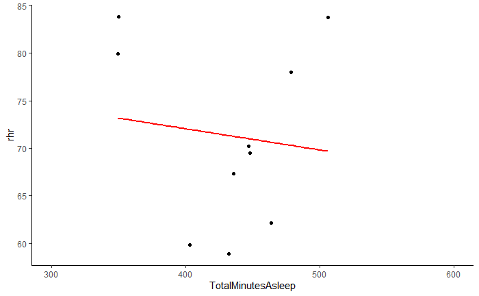

```r
ggplot(user_info, aes(x = TotalMinutesAsleep, y = rhr)) + xlim(300, 600) + geom_point()  + geom_smooth(method=lm , color="red", se=FALSE) + theme_classic()
```

There’s a correlation, even though very weak, between minutes asleep per day and RHR. /

#### Calories burned vs rhr

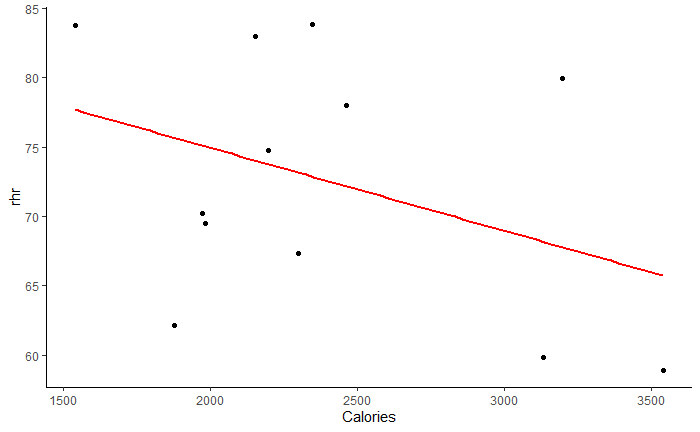

```r
corr_calories_rhr <-  ggplot(user_info, aes(x = Calories, y = rhr)) + geom_point() + geom_smooth(method=lm , color="red", se=FALSE) + theme_classic()
corr_calories_rhr
```

We can see a negative correlation between Calories burned during the day and RHR/

#### Phisycal activity vs rhr

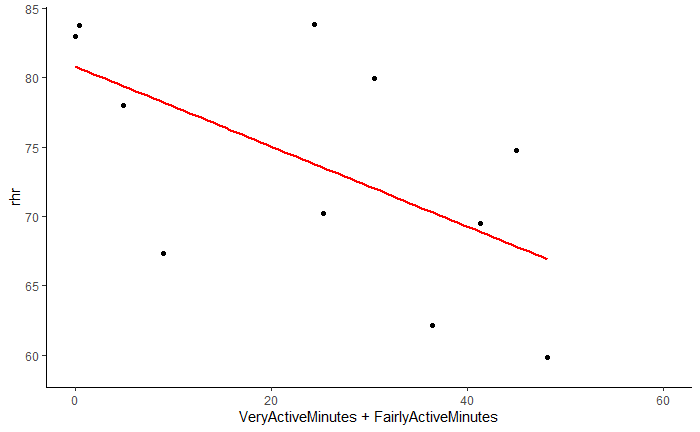

```r
corr_active_rhr <- ggplot(user_info, aes(x = VeryActiveMinutes + FairlyActiveMinutes, y = rhr)) + xlim(0, 60) + geom_point() + geom_smooth(method=lm , color="red", se=FALSE) + theme_classic()
corr_active_rhr
```

We can see a clear negative correlation between praticants of at least moderate exercise. /

#### Steps per day and RHR

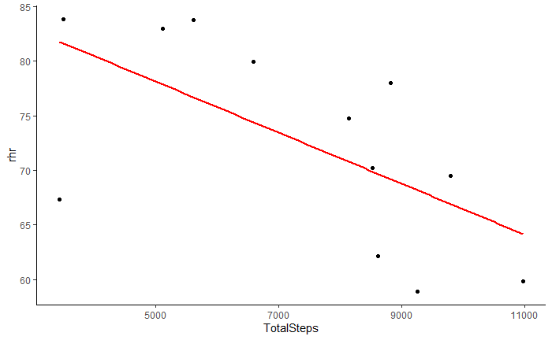

```r
corr_steps_rhr <- ggplot(user_info, aes(x = TotalSteps, y = rhr)) + geom_point() + geom_smooth(method=lm , color="red", se=FALSE) + theme_classic()
corr_steps_rhr
```

As expected given the previous results, the amount of steps taken per day has a high negative correlation with RHR. /

#### Viewing stats by group

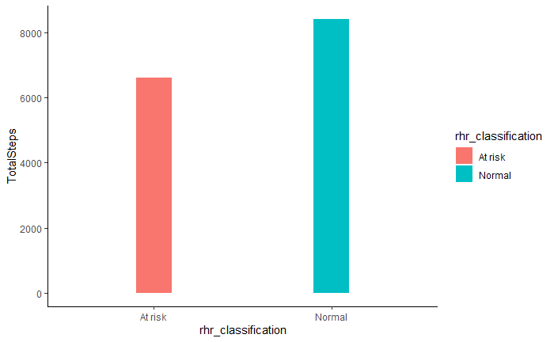

```r
ggplot(data = user_info, aes(x = rhr_classification, y = TotalSteps, fill = rhr_classification)) + geom_bar(stat = "summary", fun = "mean", width = 0.2) + theme_classic()
```

As expected users ‘at risk’ take 2000 less steps than recommended by the WHO, and ‘normal’ risk users are a little above average.

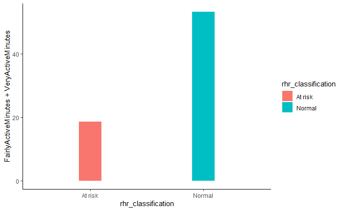

```r
ggplot(data = user_info, aes(x = rhr_classification, y = FairlyActiveMinutes + VeryActiveMinutes, fill = rhr_classification)) + geom_bar(stat = "summary", fun = "mean", width = 0.2) + theme_classic()
```

And also as expected, taking into account the WHO directives, people ‘at risk’ do less than 2/3 of recommended time of intense physical activities(30min/day), while users in ‘normal’ RHRs average at least 50% more.

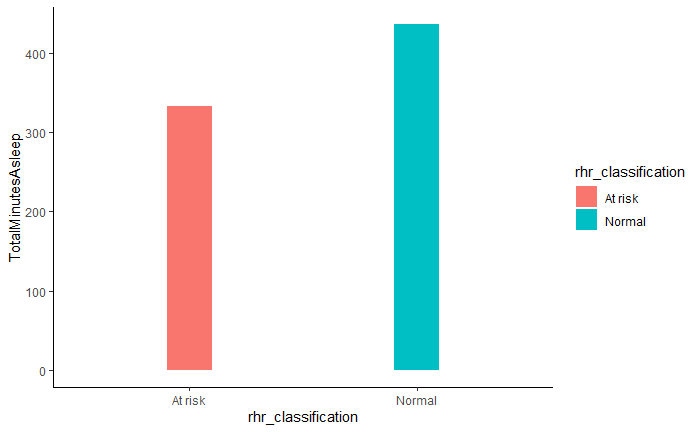

```r
ggplot(data = user_info, aes(x = rhr_classification, y = TotalMinutesAsleep, fill = rhr_classification)) + geom_bar(stat = "summary", fun = "mean", width = 0.2) + theme_classic()
```

### In summary

> People who regularly exercise more than 30min/day, take more than 8000 steps and sleep at least 7hrs/per night are at less risk of cardiac diseases than those who do not. This is using RHR as a metric, since a lower average is related to a better health of the hearth and a lower chance of cardiac arrests and such.

## Conclusion

### Recomendations

- Add as a metric for the users their RHR.
- If they are at risk, prompt them to complete at least 30 minutes of active exercise or 8000 steps trough the day.
- If users are classified with ‘abnormal’ RHR, recommend visiting a doctor.
- Improve sleep metrics, 1/3 of adults suffer from sleep deprivation. A sleep companion can be even spun-off as a premium feature for the Bellabeat app.